# 04-quarto

Author

Milo Coolman

# 4.1 Reproducibility

### Exercises 1-2

1. Quarto is a way to integrate R code with words so as to make writing explanations of your code easier, whereas R Scripts are purely for code, almost like the same as for CS classes where you have to use comments to write any non-code explanations.
2. A Quarto analysis is more reproducible than a base r script because in the quarto document it is much easier to write explanations of what each line of code is doing. Quarto also compiles everything into 1 super easy to read document full of all code, figures, explanations, and any warnings. It also does not allow you to render unless all of the code works properly.

# 4.2 Quarto Files

fig-height: default is 7 fig-width: default is 7

*bold This is Bold text* *italic This is italic text* <youtube.com>

# Big Header

### Exercises 3-4

### Exercise 5

# 4.3

Change x and y axis labels, add title, add subtitle, add caption using + labs() x and y axis limits: xlim() + ylim() Labeling certain points or lines + geom_text() or + geom_label()

### Exercise 6

# 4.4.1

### Class Exercise 1-3, 5-7

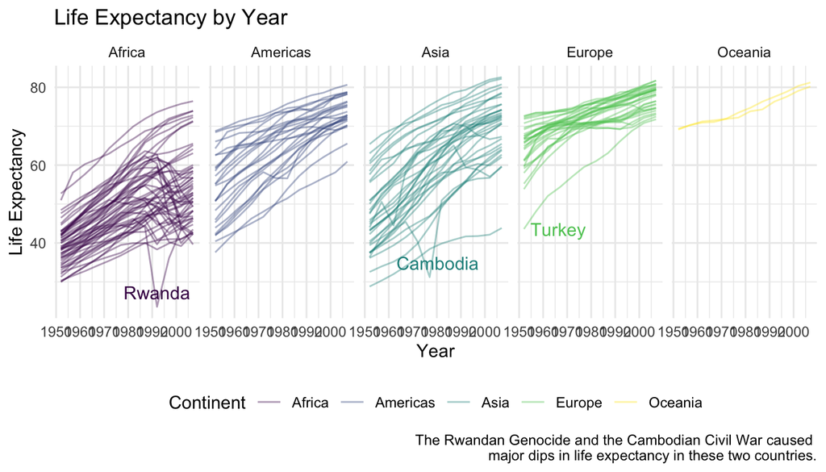

# Your Turn 1

1. Calculations done on excel and conclusion done in word
2. Changing labels and limits on y-axis;
3. Deleting 3 outliers; Could explicitly state he deleted them, but easy to forget that

# Your Turn 2

# Your Turn 3

# Your Turn 4